# Dynamics_in_WeightNormalOneLayer_SGDnoWeightDecay_public

## 1. Motivation:

The standard setup of a linear layer in neural network: $ y_{j} = \mathbf{w}_{j}^{T}\mathbf{x}+w_{0j}, \mathbf{w}_{j}\in R^{n},j = 1,2,..,m .$ The reparametrization in weight normaliztion as follows: $$ y_{j} = \frac{g\mathbf{v}_{j}^{T}}{\|\mathbf{v}_{j}\|}\mathbf{x}+w_{0j} $$ The update of $g_{j}$ and $v_{j}$ are respectivaly $$ \delta g_{j} = \frac{\mathbf{w}_{j}^{T}}{\|\mathbf{w}_{j}\|} \big<\frac{\partial E}{\partial \mathbf{w}_{j}}\big>, $$ $$ \delta \mathbf{v}_{j} = \frac{g_{j}}{\|\mathbf{v}_{j}\|} \bigg( \mathbf{I}-\frac{\mathbf{w}_{j}\mathbf{w}_{j}^{T}}{\|\mathbf{w}_{j}\|^{2}} \bigg)\big<\frac{\partial E}{\partial \mathbf{w}_{j}}\big> $$

#### The relationship of reparametrized model and original model:

$$ \begin{bmatrix} \delta w_{0j}\\ \delta \mathbf{w}_{j} \end{bmatrix} =\begin{bmatrix} 1 & \mathbf{0} \\ \mathbf{0}^{T} & \bigg[\frac{\mathbf{w}_{j}\mathbf{w}_{j}^{T}}{\|\mathbf{w}_{j}\|^{2}}+\frac{g^{2}}{\|\mathbf{v}_{j}\|^{2}}\bigg(\mathbf{I}-\frac{\mathbf{w}_{j}\mathbf{w}_{j}^{T}}{\|\mathbf{w}_{j}\|^{2}}\bigg)\bigg] \end{bmatrix} \begin{bmatrix} \textstyle \big<\frac{\partial E}{\partial w_{0j}}\big>\\ \textstyle \big<\frac{\partial E}{\partial \mathbf{w}_{j}}\big> \end{bmatrix} $$

#### We want to understand how the coefficient $\rho_{j}^{2} = \frac{g_{j}^2}{\|v_{j}\|^2} = \frac{\|w_{j}\|^{2}}{\|v_{j}\|^{2}}$ in weight normalization change in each layer as training progresses. We look into how $g_{j}^2$,$ \|v_{j}\|^2$, and $\rho_{j}$ change along the way.

## 2. Experiment details:

We did experiment on dataset CIFAR-10 (50,000 training set, 10,000 test) and used the standard setup in LeNet (shown as below), i.e.,

- SGD with momentum =0.0 and batch-size = 128 images for training (batch-size = 100 images for testing).
- Learning rate lr = 0.1 at the first 99 epochs, lr = 0.01 at epochs 100 - 199, lr = 0.001 at epochs 200 - 299.
- No Weight decay: $\hat{J}(w)=J(w)+λ‖w‖_2.$ where $\lambda =0$

### LeNet (no dropout):

- #### The weight normalization is applied to the 1st convolution layer.
- #### No dropout
- #### Overparametrized model (total parameters 290,486 > image data 50,000)

```python
_________________________________________________________________
Layer (type)                 Output Shape              Param
_________________________________________________________________
conv2d_9 (Conv2D)            (None, 28, 28, 6)         456
_________________________________________________________________
conv2d_10 (Conv2D)           (None, 24, 24, 16)        2416
_________________________________________________________________
max_pooling2d_7 (MaxPooling2 (None, 12, 12, 16)        0
_________________________________________________________________
flatten_4 (Flatten)          (None, 2304)              0
_________________________________________________________________
dense_9 (Dense)              (None, 120)               276600
_________________________________________________________________
dense_10 (Dense)             (None, 84)                10164
_________________________________________________________________
dense_11 (Dense)             (None, 10)                850
_________________________________________________________________
Total params: 290,486

Trainable params: 290,486

Non-trainable params: 0
________________________________________________________________
```

### 2. 1 The loss and accuracy in training and testing set.

### Understand the curve

- There are 2 plots (1st plot is about training loss, and 2nd plot testing accuracy)
- X-axis is Epoch
- Curves with different colors means different setup. The legend on the right or left means the following:
  - LeNet: standard setup as a baseline
  - LeNetBN: use batch normalization in all layers
  - LeNetWN1stConvLayer: use weight normalization only in the first layers.
  - LeNetWN: use weight normalization only in all layers.

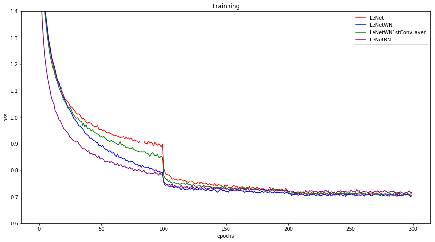

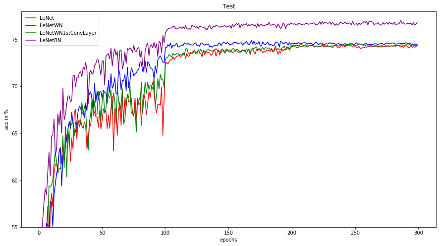

# 3. Overviews

### We look into the dynamics of weight norm that only applied to the first convolution layer instead of all!

In the follwing first three cells (each cell has 3 plots), we give you the overviews on the dynamics of $\rho_{j}$, $g_{j}^2$, and $\|v_{j}\|^2$. The following three cells tells about the dynamics of $\rho_{j}$, $g_{j}^2$, and $\|v_{j}\|^2$ for three learning rates:

- lr = 0.1 for first cell
- lr = 0.01 for second cell
- lr = 0.001 for third cell

#### Understand the three plots in each cell. Note first that ALL 3 plots share the same X-axis and Y-axis:

- Y-axis is Epoch.
- X-axis is Neuron. There are 6 neurons of the first convolution net. For each neuron, 3 filters respectively for RGB channels, so the norm $\|\mathbf{v}_{j}\| = \sum_{i=1}^{3}\|\mathbf{v}_{ij}\|, \mathbf{v}_{ij}\in R^{5\times5}, j = 1,2,...,6 $
- Z-axis is the value in $\rho_{j}$ (Left), $g_{j}$ (Middle), and $\|v_{j}\|$ (Right) respectively.

### 3.1 Observation:

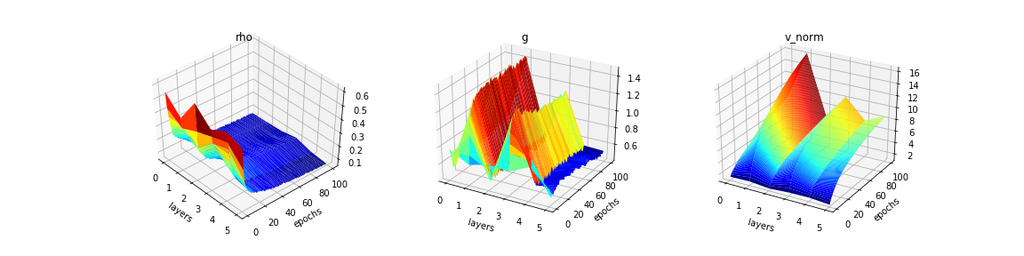

```python
plot3d(filename[0],layers_start = 0,layers_end = 6, image = 'surface')
```

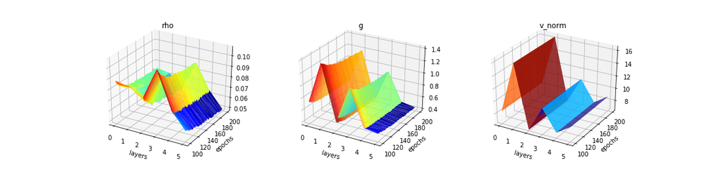

```python
plot3d(filename[1],layers_start = 0,layers_end = 6, image = 'surface')
```

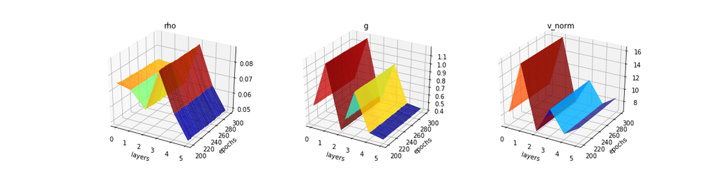

```python
plot3d(filename[2],layers_start = 0,layers_end = 6, image = 'surface')
```

## 4. Details in WeightNorm Layer

## WeightNorm at First Convolution Layer (6 neurons: Number 0 - 5)

### 4.1.1 Learning rate = 0.1

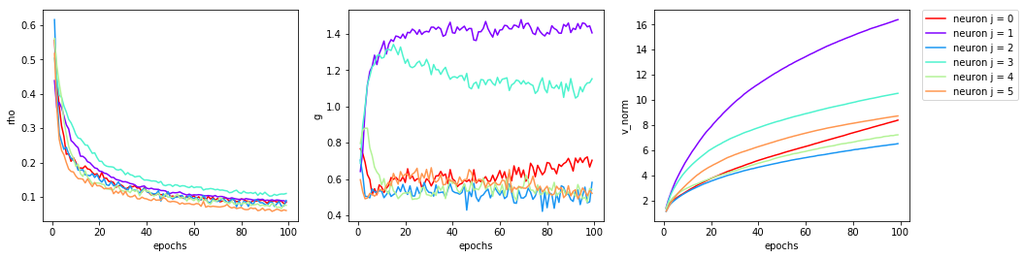

```python
%matplotlib inline
plot2d(filename[0],layers_start =0,layers_end = 6,total_layers = 6)
```

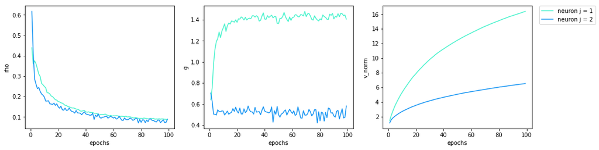

```python
plot2d(filename[0],layers_start =1,layers_end = 3,total_layers = 6)
```

### 4.1.2 Learning rate = 0.01

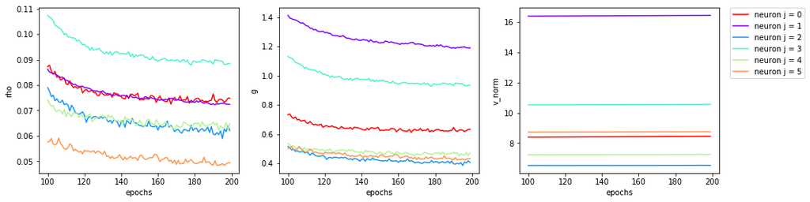

```python
plot2d(filename[1],layers_start =0,layers_end = 6)
```

### 4.4.1 Learning rate = 0.001

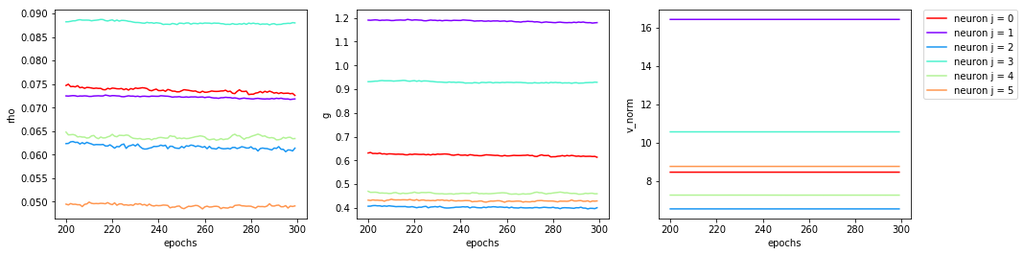

```python
plot2d(filename[2],layers_start = 0,layers_end = 6)
```